# Ford GoBike 2019 System Data

## by Sagar Bilwal

> Bay Wheels is a regional public bicycle sharing system in the San Francisco Bay Area, California operated by Motivate in a partnership with the Metropolitan Transportation Commission and the Bay Area Air Quality Management District. Bay Wheels is the first regional and large-scale bicycle sharing system deployed in California and on the West Coast of the United States. It was established as Bay Area Bike Share in August 2013. On June 28, 2017, the system officially re-launched as Ford GoBike in a partnership with Ford Motor Company. After Motivate's acquisition by Lyft, the system was subsequently renamed to Bay Wheels in June 2019.

> In this project I am exploring Ford GoBike 2019 data downloaded from https://www.lyft.com/bikes/bay-wheels/system-data

```python
# import all packages and set plots to be embedded inline
from os import listdir
import numpy as np
import pandas as pd
import matplotlib.pyplot as plt
import seaborn as sb
import requests
import json
import os, glob
from zipfile import ZipFile
from math import radians, sin, cos, acos
from io import BytesIO
import warnings
warnings.filterwarnings('ignore')
%matplotlib inline
```

## Downloading the zip files and saving it

```python
def sample_data_zip_download(data_save_path,year,prefix_url,postfix_url,alt_postfix_url):
    try:
        for month in range(1,13):
            if month <10:
                month_str = '0'+str(month)
            else:
                month_str = str(month)
            if year == '2019' and month > 4:
                postfix_url = alt_postfix_url
            system_data_url = prefix_url+ year + month_str + postfix_url
            print (month_str + ' started on ' + system_data_url)
            response = requests.get(system_data_url)
            system_data = ZipFile(BytesIO(response.content))
            #extracting contents of the zipped file and saving it 'data_save_path'
            system_data.extractall(data_save_path)
            print (month_str + ' done')
    except requests.ConnectionError:
        print('Failed to Establish Connection')
```

```python
# link for download are like https://s3.amazonaws.com/baywheels-data/201802-fordgobike-tripdata.csv.zip
#https://s3.amazonaws.com/baywheels-data/201905-baywheels-tripdata.csv.zip
data_save_path = 'Ford_GoBike_2019_System_Data'
prefix_url = 'https://s3.amazonaws.com/baywheels-data/'
# while downloading I noticed that prefix of url changed from May,2019 hence this alternative url is required
postfix_url = '-fordgobike-tripdata.csv.zip'
alt_postfix_url = '-baywheels-tripdata.csv.zip'
#downloading 2019 data
sample_data_zip_download(data_save_path,'2019',prefix_url,postfix_url,alt_postfix_url)
```

```
01 started on https://s3.amazonaws.com/baywheels-data/201901-fordgobike-tripdata.csv.zip
01 done
02 started on https://s3.amazonaws.com/baywheels-data/201902-fordgobike-tripdata.csv.zip
02 done
03 started on https://s3.amazonaws.com/baywheels-data/201903-fordgobike-tripdata.csv.zip
03 done
04 started on https://s3.amazonaws.com/baywheels-data/201904-fordgobike-tripdata.csv.zip
04 done
05 started on https://s3.amazonaws.com/baywheels-data/201905-baywheels-tripdata.csv.zip
05 done
06 started on https://s3.amazonaws.com/baywheels-data/201906-baywheels-tripdata.csv.zip
06 done
07 started on https://s3.amazonaws.com/baywheels-data/201907-baywheels-tripdata.csv.zip
07 done
08 started on https://s3.amazonaws.com/baywheels-data/201908-baywheels-tripdata.csv.zip
08 done
09 started on https://s3.amazonaws.com/baywheels-data/201909-baywheels-tripdata.csv.zip
09 done
10 started on https://s3.amazonaws.com/baywheels-data/201910-baywheels-tripdata.csv.zip
10 done
11 started on https://s3.amazonaws.com/baywheels-data/201911-baywheels-tripdata.csv.zip
11 done
12 started on https://s3.amazonaws.com/baywheels-data/201912-baywheels-tripdata.csv.zip
12 done
```

### Saving dataset

```python
#as our data is divided into 12 files according to different months I will concat whole into a single dataframe
ford_gobike_csv_list = []
for file_name in listdir(data_save_path):
    ford_gobike_csv_list.append(pd.read_csv(data_save_path+'/'+file_name,sep = ','))
ford_gobike_df = pd.concat(ford_gobike_csv_list,ignore_index= True)
```

```python
# saving all year data of 2019 in a single csv file
ford_gobike_df.to_csv('ford_gobike_2019_system_data.csv',index=False)
```

## Data Wrangling

### 1) Visualization

```python
ford_gobike_df = pd.read_csv('ford_gobike_2019_system_data.csv')
```

```python
ford_gobike_df.head(10)
```

|  | bike_id | bike_share_for_all_trip | duration_sec | end_station_id | end_station_latitude | end_station_longitude | end_station_name | end_time | rental_access_method | start_station_id | start_station_latitude | start_station_longitude | start_station_name | start_time | user_type |
| --- | --- | --- | --- | --- | --- | --- | --- | --- | --- | --- | --- | --- | --- | --- | --- |
| 0 | 4861 | No | 80825 | 196.0 | 37.808894 | -122.256460 | Grand Ave at Perkins St | 2019-02-01 16:24:49.8640 | NaN | 229.0 | 37.775745 | -122.213037 | Foothill Blvd at 42nd Ave | 2019-01-31 17:57:44.6130 | Subscriber |
| 1 | 5506 | No | 65900 | 134.0 | 37.752428 | -122.420628 | Valencia St at 24th St | 2019-02-01 15:16:54.1730 | NaN | 4.0 | 37.785881 | -122.408915 | Cyril Magnin St at Ellis St | 2019-01-31 20:58:33.8860 | Subscriber |
| 2 | 2717 | No | 62633 | 157.0 | 37.846784 | -122.291376 | 65th St at Hollis St | 2019-02-01 11:30:46.5300 | NaN | 245.0 | 37.870139 | -122.268422 | Downtown Berkeley BART | 2019-01-31 18:06:52.9240 | Customer |
| 3 | 4557 | No | 44680 | 53.0 | 37.775946 | -122.437777 | Grove St at Divisadero | 2019-02-01 08:10:50.3180 | NaN | 85.0 | 37.770083 | -122.429156 | Church St at Duboce Ave | 2019-01-31 19:46:09.7190 | Customer |
| 4 | 2100 | No | 60709 | 28.0 | 37.787168 | -122.388098 | The Embarcadero at Bryant St | 2019-02-01 07:10:51.0650 | NaN | 16.0 | 37.794130 | -122.394430 | Steuart St at Market St | 2019-01-31 14:19:01.5410 | Customer |
| 5 | 3532 | No | 6733 | 266.0 | 37.862464 | -122.264791 | Parker St at Fulton St | 2019-02-01 00:28:04.5120 | NaN | 245.0 | 37.870139 | -122.268422 | Downtown Berkeley BART | 2019-01-31 22:35:50.8130 | Subscriber |
| 6 | 5114 | No | 1188 | 146.0 | 37.742314 | -122.423181 | 30th St at San Jose Ave | 2019-02-01 00:14:27.9000 | NaN | 34.0 | 37.783988 | -122.412408 | Father Alfred E Boeddeker Park | 2019-01-31 23:54:38.9010 | Subscriber |
| 7 | 3967 | No | 1254 | 314.0 | 37.333988 | -121.894902 | Santa Clara St at Almaden Blvd | 2019-02-01 00:09:44.4970 | NaN | 318.0 | 37.330698 | -121.888979 | San Carlos St at Market St | 2019-01-31 23:48:50.0920 | Subscriber |
| 8 | 4813 | No | 3153 | 70.0 | 37.773311 | -122.444293 | Central Ave at Fell St | 2019-02-01 00:09:39.4570 | NaN | 29.0 | 37.782405 | -122.439446 | O'Farrell St at Divisadero St | 2019-01-31 23:17:05.4620 | Subscriber |
| 9 | 1976 | No | 323 | 129.0 | 37.758862 | -122.412544 | Harrison St at 20th St | 2019-02-01 00:05:11.1770 | NaN | 223.0 | 37.764765 | -122.420091 | 16th St Mission BART Station 2 | 2019-01-31 23:59:47.5680 | Subscriber |

```python
ford_gobike_df.tail(10)
```

|  | bike_id | bike_share_for_all_trip | duration_sec | end_station_id | end_station_latitude | end_station_longitude | end_station_name | end_time | rental_access_method | start_station_id | start_station_latitude | start_station_longitude | start_station_name | start_time | user_type |
| --- | --- | --- | --- | --- | --- | --- | --- | --- | --- | --- | --- | --- | --- | --- | --- |
| 2506973 | 551068 | NaN | 2336 | NaN | 37.829645 | -122.483233 | NaN | 2019-12-28 15:28:15 | app | NaN | 37.809270 | -122.475898 | NaN | 2019-12-28 14:49:19 | Subscriber |
| 2506974 | 593917 | NaN | 2297 | NaN | 37.829634 | -122.483242 | NaN | 2019-12-28 15:27:34 | app | NaN | 37.809275 | -122.475875 | NaN | 2019-12-28 14:49:17 | Subscriber |
| 2506975 | 326273 | NaN | 1816 | NaN | 37.776921 | -122.419472 | NaN | 2019-12-27 18:28:40 | app | NaN | 37.809291 | -122.414682 | NaN | 2019-12-27 17:58:23 | Subscriber |
| 2506976 | 607037 | NaN | 687 | NaN | 37.807259 | -122.410570 | NaN | 2019-12-24 18:32:47 | app | NaN | 37.809576 | -122.412358 | NaN | 2019-12-24 18:21:20 | Customer |
| 2506977 | 167109 | NaN | 711 | NaN | 37.807330 | -122.410621 | NaN | 2019-12-24 18:33:33 | app | NaN | 37.809578 | -122.412348 | NaN | 2019-12-24 18:21:41 | Customer |
| 2506978 | 719651 | NaN | 731 | NaN | 37.807573 | -122.421681 | NaN | 2019-12-28 18:49:40 | app | NaN | 37.809731 | -122.409855 | NaN | 2019-12-28 18:37:29 | Subscriber |
| 2506979 | 655411 | NaN | 748 | NaN | 37.807558 | -122.421638 | NaN | 2019-12-28 18:49:53 | app | NaN | 37.809768 | -122.409797 | NaN | 2019-12-28 18:37:24 | Subscriber |
| 2506980 | 936881 | NaN | 1044 | NaN | 37.807225 | -122.408850 | NaN | 2019-12-26 14:43:02 | app | NaN | 37.810183 | -122.410271 | NaN | 2019-12-26 14:25:37 | Subscriber |
| 2506981 | 397539 | NaN | 326 | NaN | 37.803143 | -122.414373 | NaN | 2019-12-30 20:41:09 | app | NaN | 37.810471 | -122.417386 | NaN | 2019-12-30 20:35:43 | Subscriber |
| 2506982 | 662304 | NaN | 4023 | NaN | 37.810970 | -122.418054 | NaN | 2019-12-31 20:33:52 | app | NaN | 37.811042 | -122.418149 | NaN | 2019-12-31 19:26:48 | Subscriber |

```python
ford_gobike_df.sample(10)
```

|  | bike_id | bike_share_for_all_trip | duration_sec | end_station_id | end_station_latitude | end_station_longitude | end_station_name | end_time | rental_access_method | start_station_id | start_station_latitude | start_station_longitude | start_station_name | start_time | user_type |
| --- | --- | --- | --- | --- | --- | --- | --- | --- | --- | --- | --- | --- | --- | --- | --- |
| 1793364 | 12354 | No | 677 | 26.0 | 37.787290 | -122.394380 | 1st St at Folsom St | 2019-09-20 08:22:53.6400 | NaN | 30.0 | 37.776598 | -122.395282 | San Francisco Caltrain (Townsend St at 4th St) | 2019-09-20 08:11:36.0030 | Subscriber |
| 126892 | 3476 | No | 1552 | 160.0 | 37.805318 | -122.294837 | West Oakland BART Station | 2019-01-13 15:49:15.4120 | NaN | 265.0 | 37.858868 | -122.291209 | Ninth St at Parker St | 2019-01-13 15:23:22.7930 | Subscriber |
| 449033 | 6323 | No | 330 | 131.0 | 37.755000 | -122.425728 | 22nd St at Dolores St | 2019-03-22 23:03:05.5460 | NaN | 106.0 | 37.763242 | -122.430675 | Sanchez St at 17th St | 2019-03-22 22:57:35.0240 | Subscriber |
| 1321770 | 3090 | No | 470 | 25.0 | 37.786928 | -122.398113 | Howard St at 2nd St | 2019-07-17 11:05:12.2410 | NaN | 13.0 | 37.794231 | -122.402923 | Commercial St at Montgomery St | 2019-07-17 10:57:21.7630 | Subscriber |
| 2026551 | 3077 | No | 2074 | 459.0 | 37.753123 | -122.405393 | Utah St at 24th St | 2019-10-19 14:06:32.0010 | NaN | 384.0 | 37.794160 | -122.421568 | Jackson St at Polk St | 2019-10-19 13:31:57.8890 | Subscriber |
| 1005109 | 1360 | No | 697 | 37.0 | 37.785377 | -122.396906 | 2nd St at Folsom St | 2019-05-08 15:17:50.9390 | NaN | 77.0 | 37.773507 | -122.416040 | 11th St at Natoma St | 2019-05-08 15:06:13.1650 | Subscriber |
| 2151686 | 1307 | No | 617 | 197.0 | 37.808848 | -122.249680 | El Embarcadero at Grand Ave | 2019-10-03 08:48:04.7260 | NaN | 182.0 | 37.809369 | -122.267951 | 19th Street BART Station | 2019-10-03 08:37:47.3720 | Subscriber |
| 1775907 | 9641 | No | 2317 | 279.0 | 37.339146 | -121.884105 | Santa Clara St at 7th St | 2019-09-22 20:20:02.0470 | NaN | 279.0 | 37.339146 | -121.884105 | Santa Clara St at 7th St | 2019-09-22 19:41:24.3770 | Customer |
| 2271912 | 10189 | No | 509 | 15.0 | 37.795392 | -122.394203 | San Francisco Ferry Building (Harry Bridges Pl... | 2019-11-13 07:30:05.8940 | NaN | 465.0 | 37.776329 | -122.394438 | San Francisco Caltrain Station (King St at 4th... | 2019-11-13 07:21:35.9440 | Subscriber |
| 1403599 | 2634 | No | 983 | 15.0 | 37.795392 | -122.394203 | San Francisco Ferry Building (Harry Bridges Pl... | 2019-07-02 17:28:48.7660 | NaN | 81.0 | 37.775880 | -122.393170 | Berry St at 4th St | 2019-07-02 17:12:25.1170 | Subscriber |

```python
ford_gobike_df.shape
```

```
(2506983, 15)
```

```python
ford_gobike_df.info()
```

```
<class 'pandas.core.frame.DataFrame'>
RangeIndex: 2506983 entries, 0 to 2506982
Data columns (total 15 columns):
 #   Column                   Dtype
---  ------                   -----
 0   bike_id                  int64
 1   bike_share_for_all_trip  object
 2   duration_sec             int64
 3   end_station_id           float64
 4   end_station_latitude     float64
 5   end_station_longitude    float64
 6   end_station_name         object
 7   end_time                 object
 8   rental_access_method     object
 9   start_station_id         float64
 10  start_station_latitude   float64
 11  start_station_longitude  float64
 12  start_station_name       object
 13  start_time               object
 14  user_type                object
dtypes: float64(6), int64(2), object(7)
memory usage: 286.9+ MB
```

```python
ford_gobike_df.isnull().sum()
```

```
bike_id                          0
bike_share_for_all_trip     243259
duration_sec                     0
end_station_id               82902
end_station_latitude             0
end_station_longitude            0
end_station_name             82350
end_time                         0
rental_access_method       2386145
start_station_id             80734
start_station_latitude           0
start_station_longitude          0
start_station_name           80133
start_time                       0
user_type                        0
dtype: int64
```

```python
ford_gobike_df.describe().transpose()
```

|  | count | mean | std | min | 25% | 50% | 75% | max |
| --- | --- | --- | --- | --- | --- | --- | --- | --- |
| bike_id | 2506983.0 | 27898.327162 | 114606.651187 | 4.000000 | 1952.000000 | 4420.000000 | 9682.000000 | 999941.00 |
| duration_sec | 2506983.0 | 807.648330 | 1974.713981 | 60.000000 | 359.000000 | 571.000000 | 887.000000 | 912110.00 |
| end_station_id | 2424081.0 | 142.704424 | 121.429649 | 3.000000 | 43.000000 | 101.000000 | 239.000000 | 498.00 |
| end_station_latitude | 2506983.0 | 37.764219 | 0.239289 | 0.000000 | 37.770030 | 37.780760 | 37.795873 | 45.51 |
| end_station_longitude | 2506983.0 | -122.345908 | 0.708042 | -122.514287 | -122.411726 | -122.398113 | -122.293400 | 0.00 |
| start_station_id | 2426249.0 | 146.504749 | 122.317102 | 3.000000 | 47.000000 | 105.000000 | 243.000000 | 498.00 |
| start_station_latitude | 2506983.0 | 37.765064 | 0.136370 | 0.000000 | 37.769305 | 37.780526 | 37.795393 | 45.51 |
| start_station_longitude | 2506983.0 | -122.349919 | 0.308965 | -122.514299 | -122.413004 | -122.398285 | -122.291415 | 0.00 |

```python
ford_gobike_df.bike_id.nunique()
```

```
11070
```

```python
ford_gobike_df.bike_id.value_counts()
```

```
3135      912
3146      911
3569      889
3249      882
1502      882
         ...
3973        1
655034      1
92          1
3214        1
6271        1
Name: bike_id, Length: 11070, dtype: int64
```

```python
ford_gobike_df.bike_share_for_all_trip.nunique()
```

```
2
```

```python
ford_gobike_df.bike_share_for_all_trip.value_counts()
```

```
No     2086152
Yes     177572
Name: bike_share_for_all_trip, dtype: int64
```

```python
ford_gobike_df.rental_access_method.nunique()
```

```
2
```

```python
ford_gobike_df.rental_access_method.value_counts()
```

```
app        108010
clipper     12828
Name: rental_access_method, dtype: int64
```

```python
ford_gobike_df.user_type.nunique()
```

```
2
```

```python
ford_gobike_df.user_type.value_counts()
```

```
Subscriber    2021166
Customer       485817
Name: user_type, dtype: int64
```

```python
ford_gobike_df.end_station_name.nunique()
```

```
446
```

```python
ford_gobike_df.end_station_name.value_counts(dropna=False)
```

```
NaN                                                          82350
San Francisco Caltrain Station 2  (Townsend St at 4th St)    52146
San Francisco Caltrain (Townsend St at 4th St)               50943
San Francisco Ferry Building (Harry Bridges Plaza)           48180
Montgomery St BART Station (Market St at 2nd St)             47886
                                                             ...
Mercado Way at Sierra Rd                                         4
Prototype Lab                                                    4
San Jose Depot                                                   2
Philly Demo                                                      2
Emeryville Depot                                                 1
Name: end_station_name, Length: 447, dtype: int64
```

```python
ford_gobike_df.start_station_name.nunique()
```

```
446
```

```python
ford_gobike_df.start_station_name.value_counts(dropna=False)
```

```
NaN                                                   80133
Market St at 10th St                                  45058
Berry St at 4th St                                    42962
San Francisco Caltrain (Townsend St at 4th St)        40302
San Francisco Ferry Building (Harry Bridges Plaza)    39016
                                                      ...
Prototype Lab                                             4
San Jose Depot                                            3
Mercado Way at Sierra Rd                                  3
Philly Demo                                               2
SF Test Station                                           1
Name: start_station_name, Length: 447, dtype: int64
```

```python
type(ford_gobike_df.start_time[0])
```

```
str
```

```python
type(ford_gobike_df.end_time[0])
```

```
str
```

### Cleaning the dataset

#### Before the visualization it is necessary that I clean the dataset hence following changes will be made

##### i) Convert start and end time to timestamp from string, dividing it into three columns i.e. month, day, hour and converting duration_sec into duration_min as lowest value is 60.

##### ii) Drop rental_access_method

##### iii) Find distance between end and start station using latitude and longitude

##### iv) Dropping all null values rows from the dataset

```python
ford_gobike_copy_df = ford_gobike_df.copy()
```

#### Define

Start and end time are stored as string hence have to be converted to timestamp and the further dividing into three columns each i.e. month, day and hour these three column will help in figuring out when highest users use the bikes.

#### Code

```python
# converting to timestamp

ford_gobike_copy_df.start_time = pd.to_datetime(ford_gobike_copy_df.start_time)
ford_gobike_copy_df.end_time = pd.to_datetime(ford_gobike_copy_df.end_time)

# now handling start and end time as timestamp and dividing it into month, days and hour
# start_time

ford_gobike_copy_df['start_month'] = ford_gobike_copy_df.start_time.dt.strftime('%b')
ford_gobike_copy_df['start_day'] = ford_gobike_copy_df.start_time.dt.strftime('%a')
ford_gobike_copy_df['start_hour'] = ford_gobike_copy_df.start_time.map(lambda x: x.hour)

# end_time

ford_gobike_copy_df['end_month'] = ford_gobike_copy_df.end_time.dt.strftime('%b')
ford_gobike_copy_df['end_day'] = ford_gobike_copy_df.end_time.dt.strftime('%a')
ford_gobike_copy_df['end_hour'] = ford_gobike_copy_df.end_time.map(lambda x: x.hour)

# also convert duration from seconds to minutes as seconds value is very large and minutes will be easy to visualize
ford_gobike_copy_df['duration_min']= ford_gobike_copy_df.duration_sec.map(lambda x: x/60)
```

```python
# dropping start_time and end_time as we do not require it for visualization
ford_gobike_copy_df.drop(['start_time','end_time','duration_sec'], axis=1, inplace = True)
```

#### Test

```python
ford_gobike_df.info()
```

```
<class 'pandas.core.frame.DataFrame'>
RangeIndex: 2506983 entries, 0 to 2506982
Data columns (total 15 columns):
 #   Column                   Dtype
---  ------                   -----
 0   bike_id                  int64
 1   bike_share_for_all_trip  object
 2   duration_sec             int64
 3   end_station_id           float64
 4   end_station_latitude     float64
 5   end_station_longitude    float64
 6   end_station_name         object
 7   end_time                 object
 8   rental_access_method     object
 9   start_station_id         float64
 10  start_station_latitude   float64
 11  start_station_longitude  float64
 12  start_station_name       object
 13  start_time               object
 14  user_type                object
dtypes: float64(6), int64(2), object(7)
memory usage: 286.9+ MB
```

```python
ford_gobike_copy_df.head()
```

|  | bike_id | bike_share_for_all_trip | end_station_id | end_station_latitude | end_station_longitude | end_station_name | rental_access_method | start_station_id | start_station_latitude | start_station_longitude | start_station_name | user_type | start_month | start_day | start_hour | end_month | end_day | end_hour | duration_min |
| --- | --- | --- | --- | --- | --- | --- | --- | --- | --- | --- | --- | --- | --- | --- | --- | --- | --- | --- | --- |
| 0 | 4861 | No | 196.0 | 37.808894 | -122.256460 | Grand Ave at Perkins St | NaN | 229.0 | 37.775745 | -122.213037 | Foothill Blvd at 42nd Ave | Subscriber | Jan | Thu | 17 | Feb | Fri | 16 | 1347.083333 |
| 1 | 5506 | No | 134.0 | 37.752428 | -122.420628 | Valencia St at 24th St | NaN | 4.0 | 37.785881 | -122.408915 | Cyril Magnin St at Ellis St | Subscriber | Jan | Thu | 20 | Feb | Fri | 15 | 1098.333333 |
| 2 | 2717 | No | 157.0 | 37.846784 | -122.291376 | 65th St at Hollis St | NaN | 245.0 | 37.870139 | -122.268422 | Downtown Berkeley BART | Customer | Jan | Thu | 18 | Feb | Fri | 11 | 1043.883333 |
| 3 | 4557 | No | 53.0 | 37.775946 | -122.437777 | Grove St at Divisadero | NaN | 85.0 | 37.770083 | -122.429156 | Church St at Duboce Ave | Customer | Jan | Thu | 19 | Feb | Fri | 8 | 744.666667 |
| 4 | 2100 | No | 28.0 | 37.787168 | -122.388098 | The Embarcadero at Bryant St | NaN | 16.0 | 37.794130 | -122.394430 | Steuart St at Market St | Customer | Jan | Thu | 14 | Feb | Fri | 7 | 1011.816667 |

#### Define

Dropping rental_access_method column as 95% of the values are not available hence it will not help in visualization.

#### Code

```python
ford_gobike_copy_df.drop('rental_access_method',axis =1, inplace=True)
```

#### Test

```python
ford_gobike_copy_df.columns
```

```
Index(['bike_id', 'bike_share_for_all_trip', 'end_station_id',
       'end_station_latitude', 'end_station_longitude', 'end_station_name',
       'start_station_id', 'start_station_latitude', 'start_station_longitude',
       'start_station_name', 'user_type', 'start_month', 'start_day',
       'start_hour', 'end_month', 'end_day', 'end_hour', 'duration_min'],
      dtype='object')
```

#### Define

Dropping all null values from the dataset which is mostly present in bike_share_for_all_trip which is about 9.7% of data

#### Code

```python
ford_gobike_copy_df.dropna(inplace=True)
```

#### Test

```python
ford_gobike_copy_df.isnull().sum()
```

```
bike_id                    0
bike_share_for_all_trip    0
end_station_id             0
end_station_latitude       0
end_station_longitude      0
end_station_name           0
start_station_id           0
start_station_latitude     0
start_station_longitude    0
start_station_name         0
user_type                  0
start_month                0
start_day                  0
start_hour                 0
end_month                  0
end_day                    0
end_hour                   0
duration_min               0
dtype: int64
```

```python
(ford_gobike_df.shape[0]-ford_gobike_copy_df.shape[0])/ford_gobike_df.shape[0]
```

```
0.09732973857421451
```

About 9.7% of rows were dropped to remove all null values from the dataset

#### Define

To find distance between start and end station using the latitude and longitude

#### Code

```python
# calculating distance between start and end point in kilometers
ford_gobike_copy_df['distance_miles'] = 3958.756 * 2 * \
np.arcsin(np.sqrt(np.sin((np.radians(ford_gobike_copy_df['end_station_latitude']) - np.radians(ford_gobike_copy_df['start_station_latitude']))/2)**2 + \
                  np.cos(np.radians(ford_gobike_copy_df['start_station_latitude']))
                * np.cos(np.radians(ford_gobike_copy_df['end_station_latitude'])) *
                  np.sin((np.radians(ford_gobike_copy_df['end_station_longitude']) - np.radians(ford_gobike_copy_df['start_station_longitude']))/2)**2))
```

```python
# dropping lat and long as it will not be used in further visualization
ford_gobike_copy_df.drop(['end_station_latitude','end_station_longitude','start_station_latitude','start_station_longitude'], axis=1, inplace = True)
```

#### Test

```python
ford_gobike_copy_df.head()
```

|  | bike_id | bike_share_for_all_trip | end_station_id | end_station_name | start_station_id | start_station_name | user_type | start_month | start_day | start_hour | end_month | end_day | end_hour | duration_min | distance_miles |
| --- | --- | --- | --- | --- | --- | --- | --- | --- | --- | --- | --- | --- | --- | --- | --- |
| 0 | 4861 | No | 196.0 | Grand Ave at Perkins St | 229.0 | Foothill Blvd at 42nd Ave | Subscriber | Jan | Thu | 17 | Feb | Fri | 16 | 1347.083333 | 3.296498 |
| 1 | 5506 | No | 134.0 | Valencia St at 24th St | 4.0 | Cyril Magnin St at Ellis St | Subscriber | Jan | Thu | 20 | Feb | Fri | 15 | 1098.333333 | 2.398262 |
| 2 | 2717 | No | 157.0 | 65th St at Hollis St | 245.0 | Downtown Berkeley BART | Customer | Jan | Thu | 18 | Feb | Fri | 11 | 1043.883333 | 2.042508 |
| 3 | 4557 | No | 53.0 | Grove St at Divisadero | 85.0 | Church St at Duboce Ave | Customer | Jan | Thu | 19 | Feb | Fri | 8 | 744.666667 | 0.621143 |
| 4 | 2100 | No | 28.0 | The Embarcadero at Bryant St | 16.0 | Steuart St at Market St | Customer | Jan | Thu | 14 | Feb | Fri | 7 | 1011.816667 | 0.592387 |

```python
ford_gobike_copy_df.shape
```

```
(2262979, 15)
```

```python
ford_gobike_copy_df.describe().transpose()
```

|  | count | mean | std | min | 25% | 50% | 75% | max |
| --- | --- | --- | --- | --- | --- | --- | --- | --- |
| bike_id | 2262979.0 | 4796.712072 | 3692.328371 | 4.000000 | 1827.000000 | 3625.000000 | 6486.000000 | 13112.000000 |
| end_station_id | 2262979.0 | 141.593220 | 120.294833 | 3.000000 | 43.000000 | 101.000000 | 239.000000 | 493.000000 |
| start_station_id | 2262979.0 | 145.112012 | 121.095856 | 3.000000 | 47.000000 | 104.000000 | 241.000000 | 493.000000 |
| start_hour | 2262979.0 | 13.542374 | 4.799467 | 0.000000 | 9.000000 | 14.000000 | 17.000000 | 23.000000 |
| end_hour | 2262979.0 | 13.707215 | 4.823762 | 0.000000 | 9.000000 | 14.000000 | 18.000000 | 23.000000 |
| duration_min | 2262979.0 | 13.448840 | 32.036763 | 1.016667 | 5.966667 | 9.483333 | 14.733333 | 1436.950000 |
| distance_miles | 2262979.0 | 1.225264 | 36.993521 | 0.000000 | 0.578306 | 0.902583 | 1.384819 | 7953.382382 |

```python
ford_gobike_copy_df.query('start_station_id == end_station_id ').sample(20)
```

|  | bike_id | bike_share_for_all_trip | end_station_id | end_station_name | start_station_id | start_station_name | user_type | start_month | start_day | start_hour | end_month | end_day | end_hour | duration_min | distance_miles |
| --- | --- | --- | --- | --- | --- | --- | --- | --- | --- | --- | --- | --- | --- | --- | --- |
| 555245 | 6365 | No | 31.0 | Raymond Kimbell Playground | 31.0 | Raymond Kimbell Playground | Subscriber | Mar | Mon | 18 | Mar | Mon | 21 | 148.783333 | 0.0 |
| 1281759 | 584 | No | 247.0 | Fulton St at Bancroft Way | 247.0 | Fulton St at Bancroft Way | Subscriber | Jul | Wed | 21 | Jul | Wed | 21 | 1.216667 | 0.0 |
| 108110 | 5469 | No | 324.0 | Union Square (Powell St at Post St) | 324.0 | Union Square (Powell St at Post St) | Subscriber | Jan | Thu | 14 | Jan | Thu | 15 | 30.883333 | 0.0 |
| 1183145 | 1217 | No | 5.0 | Powell St BART Station (Market St at 5th St) | 5.0 | Powell St BART Station (Market St at 5th St) | Subscriber | Jun | Mon | 13 | Jun | Mon | 13 | 29.316667 | 0.0 |
| 741632 | 4758 | No | 399.0 | Bay St at Fillmore St | 399.0 | Bay St at Fillmore St | Customer | Apr | Sat | 15 | Apr | Sat | 16 | 70.016667 | 0.0 |
| 1284551 | 152 | Yes | 239.0 | Bancroft Way at Telegraph Ave | 239.0 | Bancroft Way at Telegraph Ave | Subscriber | Jul | Wed | 15 | Jul | Wed | 16 | 39.783333 | 0.0 |
| 1203607 | 4217 | No | 311.0 | Paseo De San Antonio at 2nd St | 311.0 | Paseo De San Antonio at 2nd St | Subscriber | Jun | Thu | 19 | Jun | Thu | 19 | 1.050000 | 0.0 |
| 628314 | 4983 | No | 112.0 | Harrison St at 17th St | 112.0 | Harrison St at 17th St | Subscriber | Mar | Fri | 11 | Mar | Fri | 12 | 18.916667 | 0.0 |
| 1056298 | 2270 | No | 61.0 | Howard St at 8th St | 61.0 | Howard St at 8th St | Customer | Jun | Sun | 10 | Jun | Sun | 10 | 29.583333 | 0.0 |
| 974613 | 3098 | No | 390.0 | Indiana St at Cesar Chavez St | 390.0 | Indiana St at Cesar Chavez St | Subscriber | May | Mon | 17 | May | Mon | 17 | 1.416667 | 0.0 |
| 2291105 | 3149 | No | 265.0 | Ninth St at Parker St | 265.0 | Ninth St at Parker St | Customer | Nov | Sun | 11 | Nov | Sun | 12 | 75.066667 | 0.0 |
| 164115 | 4505 | Yes | 221.0 | 6th Ave at E 12th St (Temporary Location) | 221.0 | 6th Ave at E 12th St (Temporary Location) | Subscriber | Jan | Mon | 15 | Jan | Mon | 17 | 99.716667 | 0.0 |
| 472439 | 5073 | No | 218.0 | DeFremery Park | 218.0 | DeFremery Park | Subscriber | Mar | Wed | 13 | Mar | Wed | 14 | 88.016667 | 0.0 |
| 1600594 | 2673 | Yes | 289.0 | 5th St at Taylor St | 289.0 | 5th St at Taylor St | Subscriber | Aug | Sat | 20 | Aug | Sat | 21 | 39.500000 | 0.0 |
| 2023194 | 3054 | Yes | 239.0 | Bancroft Way at Telegraph Ave | 239.0 | Bancroft Way at Telegraph Ave | Subscriber | Oct | Sun | 11 | Oct | Sun | 11 | 16.616667 | 0.0 |
| 1514462 | 10240 | No | 345.0 | Hubbell St at 16th St | 345.0 | Hubbell St at 16th St | Customer | Aug | Thu | 20 | Aug | Thu | 20 | 15.550000 | 0.0 |
| 53673 | 4911 | Yes | 13.0 | Commercial St at Montgomery St | 13.0 | Commercial St at Montgomery St | Subscriber | Jan | Fri | 11 | Jan | Fri | 12 | 21.016667 | 0.0 |
| 364513 | 5359 | No | 78.0 | Folsom St at 9th St | 78.0 | Folsom St at 9th St | Subscriber | Feb | Sun | 16 | Feb | Sun | 16 | 4.466667 | 0.0 |
| 815121 | 1920 | No | 349.0 | Howard St at Mary St | 349.0 | Howard St at Mary St | Customer | Apr | Sat | 18 | Apr | Sat | 19 | 28.966667 | 0.0 |
| 1268029 | 3224 | No | 225.0 | 23rd Ave at Foothill Blvd | 225.0 | 23rd Ave at Foothill Blvd | Subscriber | Jul | Sat | 20 | Jul | Sat | 20 | 7.250000 | 0.0 |

## Preliminary Wrangling

### What is the structure of the dataset?

> Initally -> Rows = 2506983; Columns = 15;

> After Cleaning -> Rows = 2262979; Columns = 15;

### What is/are the main feature(s) of interest in the dataset?

The main features of interest in my dataset will be as follows -

> 1) Most used start and end station (total 446 unique stations are available) which will help to figure out where does Ford GoBike recieve maximum users

> 2) Which time of the day/month Ford GoBike receive maximum users

> 3) Total Distance travelled and time taken by users

> 4) Difference between usage by customers and subscribers

### Features in the dataset ?

#### Before Cleaning

> According to me in case of rental_access_method it will not be of much help as almost 95% of the values are not available and also in case of bike_share_for_all_trip about 9.7% of data is not available but the available data will be enough for exploration. Also Start station and end station id will not be of any use for me as we already have station names .Hence I will mainly use 12 features for my investigation.

#### After Cleaning

> About 9.7% of rows were dropped to remove null values, few new columns were added which are as follows - 1) start_month, 2) start_day, 3) start_hour, 4) end_month, 5) end_day, 6) end_hour, 7) duration_min, 8) distance_miles and I dropped some of the columns from the dataset after which I have total 15 columns/features to help me with visualizations.

## Univariate Exploration

```python
sb.set_style('whitegrid')
sb.set_context('talk')
```

### Distribution traffic across months, days and hours

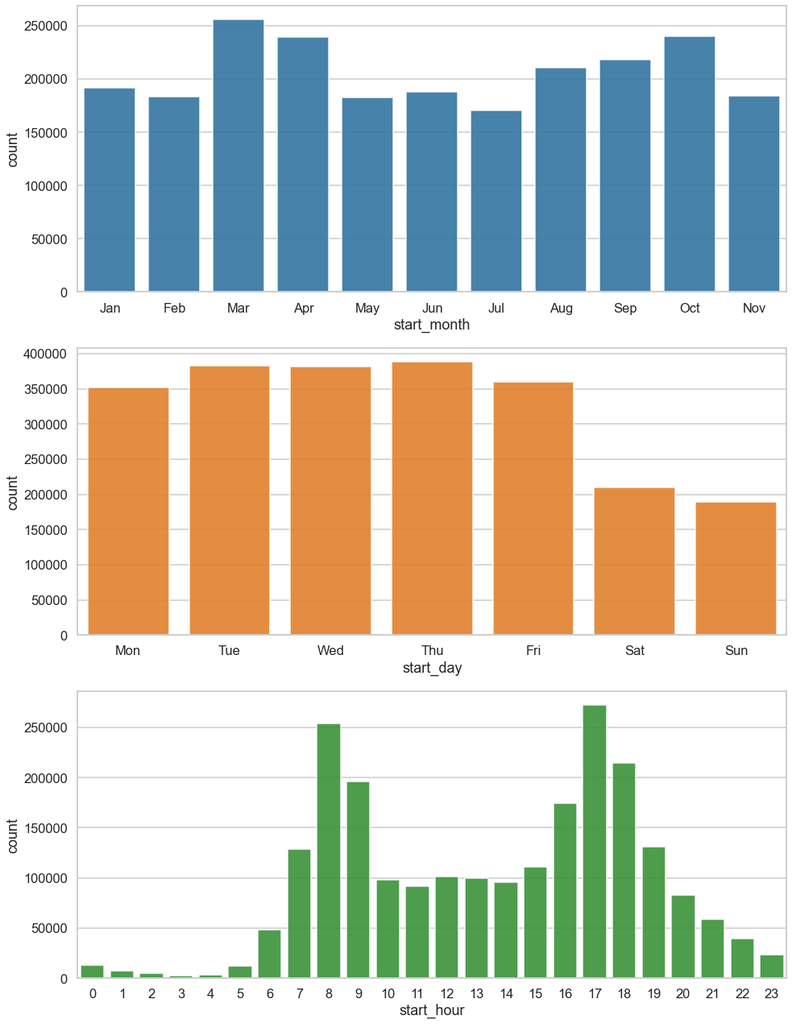

```python
# use boxplot in exploring distance in miles and duration in minutes
# use countplot for 1) type of user, 2) months, days and hours, 3) station_id/name of start and end
fig, ax = plt.subplots(nrows = 3, figsize = [14,18])
month_color = sb.color_palette()[0]
day_color = sb.color_palette()[1]
hour_color = sb.color_palette()[2]
# specifying order of days of week to make visualization more easily readable
days_of_week_order = ['Mon','Tue','Wed','Thu','Fri','Sat','Sun']
sb.countplot(data = ford_gobike_copy_df, x= 'start_month', color = month_color, ax = ax[0], alpha = 0.9)
sb.countplot(data = ford_gobike_copy_df, x= 'start_day', color = day_color, ax = ax[1], order = days_of_week_order, alpha = 0.9)
sb.countplot(data = ford_gobike_copy_df, x= 'start_hour', color = hour_color, ax = ax[2], alpha = 0.9)
plt.tight_layout()
plt.show()
```

> Looking at the above countplots following observations can be made - 1) March - April and Aug - Oct timeperiod gets increased number of users apart from this the number of user are pretty consistent about 1,80,000 in rest of the year, 2) Weekdays have more users using Ford GoBike than on weekends, 3) During office hours i.e. 7 am to 9 am and 4 pm to 7 pm have increased users while early morning the users are very less.

## Most used start and end stations

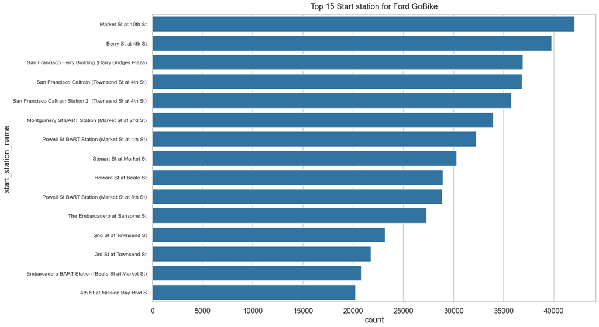

```python
plt.figure(figsize = [18,12])
start_color = sb.color_palette()[0]
sb.countplot(data = ford_gobike_copy_df, y= 'start_station_name', color = start_color, order = ford_gobike_copy_df.start_station_name.value_counts().iloc[:15].index)
plt.tick_params(axis = 'y',which = 'major',labelsize = 12)
plt.title('Top 15 Start station for Ford GoBike', y = 1.01)
plt.show()
```

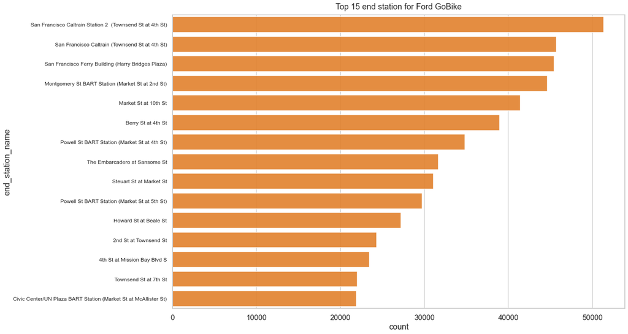

```python
plt.figure(figsize = [18,12])
end_color = sb.color_palette()[1]
sb.countplot(data = ford_gobike_copy_df, y= 'end_station_name', color = end_color, order = ford_gobike_copy_df.end_station_name.value_counts().iloc[:15].index, alpha = 0.9)
plt.tick_params(axis = 'y',which = 'major',labelsize = 12)
plt.title('Top 15 end station for Ford GoBike', y = 1.01)
plt.show()
```

> In the above two count plots top 15 start and end stations are visible out of a total of 446 available.

## Distribution of total distance travelled by the users using Ford GoBike

```python
ford_gobike_copy_df.distance_miles.value_counts()
```

```
0.000000    55384
0.814211     7940
1.349329     7582
0.878338     6240
0.595871     5719
            ...
2.929122        1
2.780375        1
3.439826        1
1.730102        1
1.451846        1
Name: distance_miles, Length: 27541, dtype: int64
```

##### In almost 55k entries the starting and ending stations are same as the user might have been taken a round trip apart from that the distance calculated is crow fly distance which will not be accurate but as dataset is huge google distance api can not be used for now

```python
ford_gobike_copy_df.distance_miles.describe(percentiles =[0.1,0.2,0.3,0.4,0.5,0.6,0.7,0.8,0.9,0.95,0.999])
```

```
count    2.262979e+06
mean     1.225264e+00
std      3.699352e+01
min      0.000000e+00
10%      3.720324e-01
20%      5.175093e-01
30%      6.394621e-01
40%      7.703117e-01
50%      9.025832e-01
60%      1.062135e+00
70%      1.270943e+00
80%      1.537476e+00
90%      1.975264e+00
95%      2.340499e+00
99.9%    4.320745e+00
max      7.953382e+03
Name: distance_miles, dtype: float64
```

#### As almost 99.9% data is having distance less than 4.5 I will drop rest of the columns

```python
# dropping all rows with distance > 45 as the data is incorrect
ford_gobike_copy_df = ford_gobike_copy_df.query('distance_miles < 4.5')
```

```python
ford_gobike_copy_df.distance_miles.describe(percentiles =[0.1,0.2,0.3,0.4,0.5,0.6,0.7,0.8,0.9,0.95,0.999])
```

```
count    2.261280e+06
mean     1.050165e+00
std      6.581796e-01
min      0.000000e+00
10%      3.719801e-01
20%      5.166922e-01
30%      6.392347e-01
40%      7.700959e-01
50%      9.021759e-01
60%      1.061671e+00
70%      1.270249e+00
80%      1.534362e+00
90%      1.968395e+00
95%      2.334384e+00
99.9%    4.107691e+00
max      4.498890e+00
Name: distance_miles, dtype: float64
```

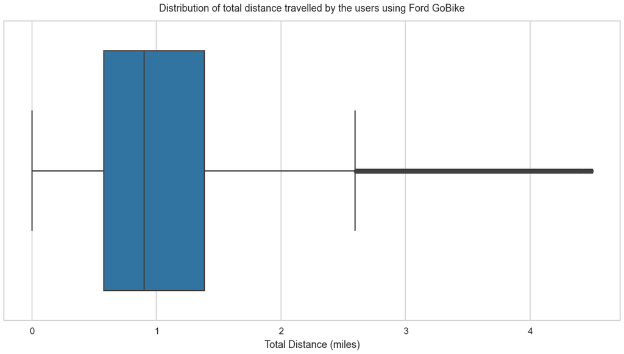

```python
plt.figure(figsize = (20,10))
sb.boxplot(data = ford_gobike_copy_df, x = 'distance_miles',orient = 'h')
plt.title('Distribution of total distance travelled by the users using Ford GoBike', y = 1.02)
plt.xlabel('Total Distance (miles)',labelpad = 8)
plt.show()
```

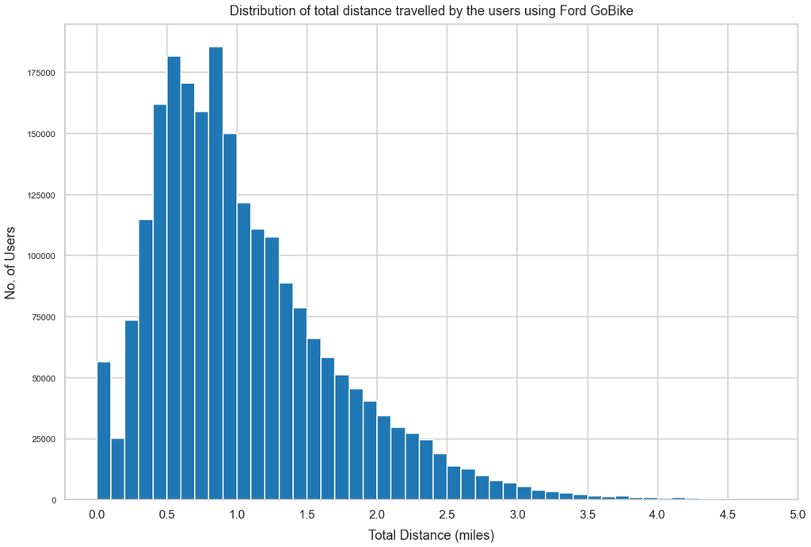

```python
plt.figure(figsize = [18,12])
bin_edges = np.arange(0,ford_gobike_copy_df.distance_miles.max()+0.1,0.1)
plt.hist(data = ford_gobike_copy_df, x= 'distance_miles',bins= bin_edges)
plt.tick_params(axis = 'y',labelsize = 12)
plt.title('Distribution of total distance travelled by the users using Ford GoBike', y = 1.01)
xtick_locs = np.arange(0,ford_gobike_copy_df.distance_miles.max()+1,0.5)
plt.xticks(xtick_locs,xtick_locs)
plt.xlabel('Total Distance (miles)', labelpad = 12)
plt.ylabel('No. of Users', labelpad = 12)
plt.show()
```

> In the above plots i.e. boxplot and countplot following observations can be made 1) Mostly people travel around 0.2 miles to 1.5 miles but as this distance calculated it straight distance from one points two other it might be lower than the actual distance between the two points on road but as dataset is large google maps api can not be used beacuse of financial constraints. Median of the distance travelled is 0.9 miles.

## Distribution of total duration for which users are using Ford GoBike

```python
ford_gobike_copy_df.duration_min.describe(percentiles =[0.1,0.2,0.3,0.4,0.5,0.6,0.7,0.8,0.9,0.95,0.98])
```

```
count    2.261280e+06
mean     1.341597e+01
std      3.182489e+01
min      1.016667e+00
10%      3.916667e+00
20%      5.316667e+00
30%      6.616667e+00
40%      7.983333e+00
50%      9.483333e+00
60%      1.120000e+01
70%      1.336667e+01
80%      1.638333e+01
90%      2.200000e+01
95%      2.905000e+01
98%      4.415000e+01
max      1.436950e+03
Name: duration_min, dtype: float64
```

#### As 98% of data has time duration (minutes) less than 45 hence rest are being dropped hence making visualization readable

```python
ford_gobike_copy_df = ford_gobike_copy_df.query('duration_min < 45')
```

```python
ford_gobike_copy_df.duration_min.describe(percentiles =[0.1,0.2,0.3,0.4,0.5,0.6,0.7,0.8,0.9,0.95,0.98])
```

```
count    2.217818e+06
mean     1.110244e+01
std      7.251979e+00
min      1.016667e+00
10%      3.883333e+00
20%      5.266667e+00
30%      6.550000e+00
40%      7.883333e+00
50%      9.333333e+00
60%      1.098333e+01
70%      1.303333e+01
80%      1.583333e+01
90%      2.060000e+01
95%      2.566667e+01
98%      3.233333e+01
max      4.498333e+01
Name: duration_min, dtype: float64
```

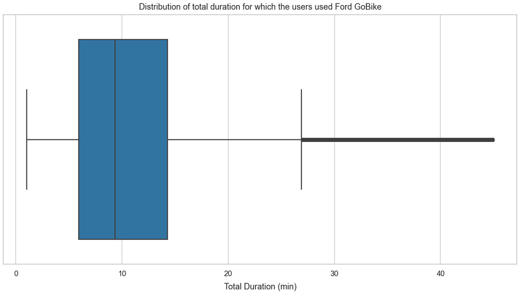

```python
plt.figure(figsize = (20,10))
sb.boxplot(data = ford_gobike_copy_df, x = 'duration_min',orient = 'h')
plt.title('Distribution of total duration for which the users used Ford GoBike',y = 1.01)
plt.xlabel('Total Duration (min)',labelpad = 12)
plt.show()
```

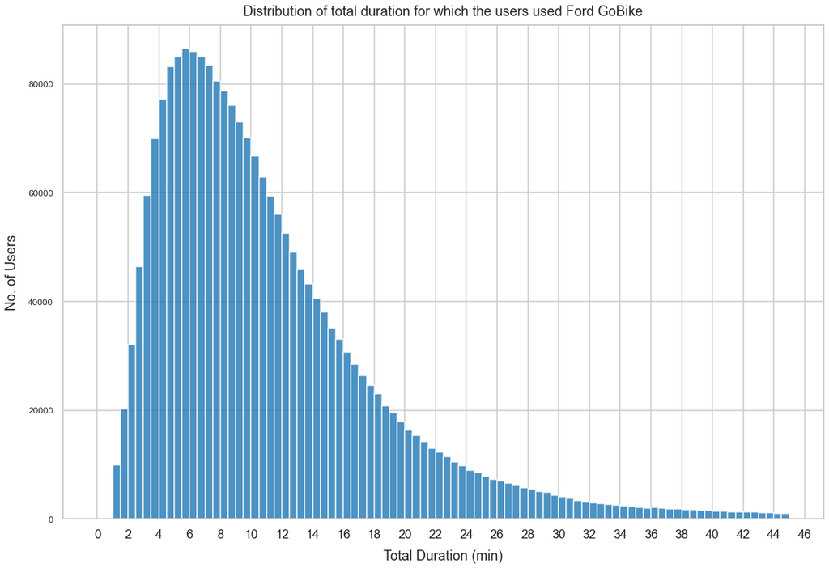

```python
plt.figure(figsize = [18,12])
bin_edges = np.arange(0,ford_gobike_copy_df.duration_min.max()+0.5,0.5)
plt.hist(data = ford_gobike_copy_df, x= 'duration_min',bins= bin_edges, alpha = 0.8)
plt.tick_params(axis = 'y',labelsize = 12)
plt.title('Distribution of total duration for which the users used Ford GoBike',y = 1.01)
xtick_locs = np.arange(0,ford_gobike_copy_df.duration_min.max()+2,2)
xtick_locs=xtick_locs.astype(int)
plt.xticks(xtick_locs,xtick_locs)
plt.xlabel('Total Duration (min)', labelpad = 12)
plt.ylabel('No. of Users', labelpad = 12)
plt.show()
```

> The median of the total duration for which is Ford GoBike is used is approximately 9.33 min. Most of the user use it between 2.5 min to 15 min

## Distribution of Subscribers vs Customers

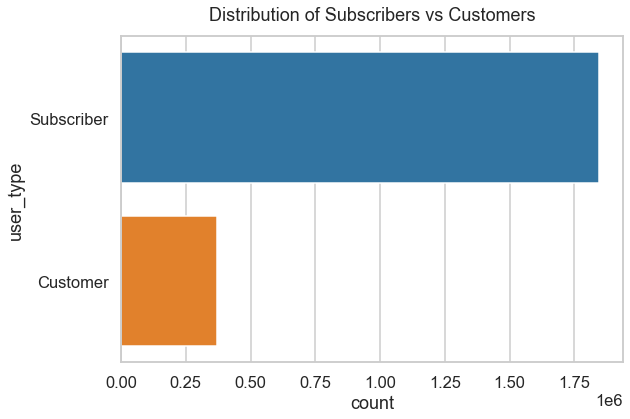

```python
plt.figure(figsize = [9,6])
sb.countplot(data = ford_gobike_copy_df, y= 'user_type')
plt.title('Distribution of Subscribers vs Customers',y = 1.03)
plt.show()
```

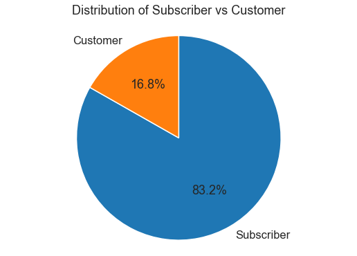

```python
plt.figure(figsize = [9,6])
user_type_counts = ford_gobike_copy_df.user_type.value_counts()
subscriber_count = user_type_counts[0]
customer_count = user_type_counts[1]
total_count = subscriber_count+customer_count
plt.pie([(subscriber_count/total_count), (customer_count/total_count)], labels = user_type_counts.index, startangle =90, counterclock = False, autopct ='%1.1f%%')
plt.axis('equal')
plt.title('Distribution of Subscriber vs Customer',y = 1.03)
plt.show()
```

> About 83.2% of users have taken subscription for Ford GoBike

```python
ford_gobike_copy_df.to_csv('ford_gobike_2019_system_data_cleaned.csv',index=False)
```

> There were some usual points in time duration and total distance columns which were not allowing visualization to happen hence I dropped those rows as mentioned below respective visualization. There were some round trips in the dataset which made the distance_km become 0 as starting and ending location was same.

> Few initial change were made by me to make data easy for visualization for example dividing timestamp column into days of weeks, months and hour which later helped me to visualize traffic distribution vary along with time

## Distribution of traffic across months, days and hours by Subscribers vs Customers

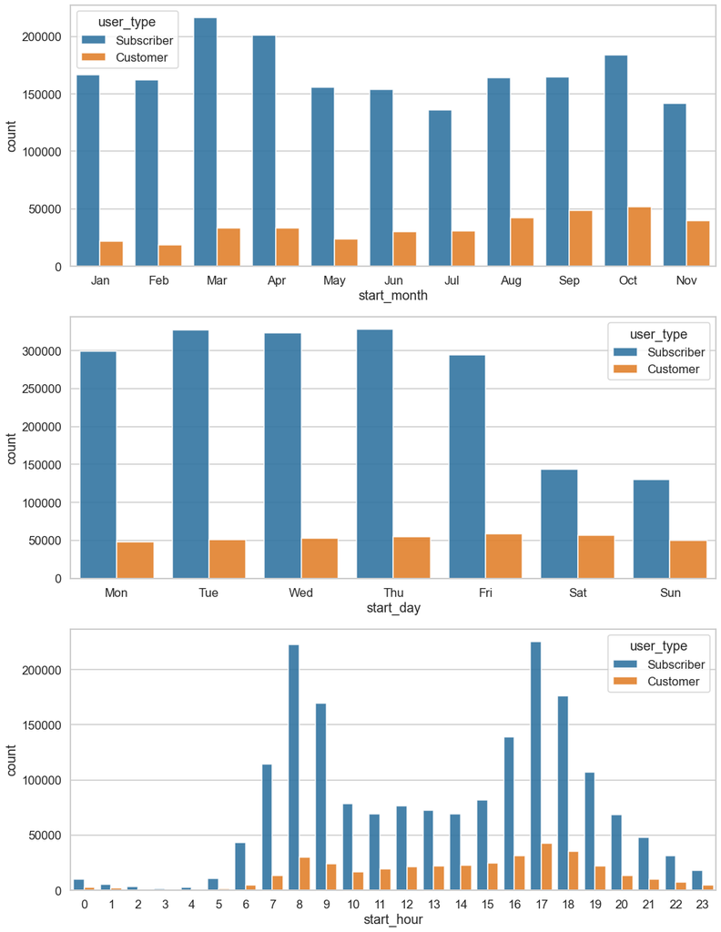

```python
fig, ax = plt.subplots(nrows = 3, figsize = [14,18])
month_color = sb.color_palette()[0]
day_color = sb.color_palette()[1]
hour_color = sb.color_palette()[2]
#, color = hour_color,
# specifying order of days of week to make visualization more easily readable
days_of_week_order = ['Mon','Tue','Wed','Thu','Fri','Sat','Sun']
sb.countplot(data = ford_gobike_copy_df, x= 'start_month', hue = 'user_type', ax = ax[0], alpha = 0.9)
sb.countplot(data = ford_gobike_copy_df, x= 'start_day', hue = 'user_type', ax = ax[1], order = days_of_week_order, alpha = 0.9)
sb.countplot(data = ford_gobike_copy_df, x= 'start_hour', hue = 'user_type', ax = ax[2], alpha = 0.9)
plt.tight_layout()
plt.show()
```

> 1) Distribution of traffic in months for subscriber and customer is similar as it first peaks in march and april and then traffic reduces in coming months but again it peaks in August to October time period. 2) There is some difference in traffic distribution in case of week as subscribers are much more during weekdays than in weekends but customers are almost same ie. around 50k during all daysof week. 3) Again in hour distribution the peaks and decline is similar for both subscriber and customer with traffic peaking 7 am to 9 am and 4 pm to 7 pm

## Distribution of total distance travelled by Subscribers vs Customers

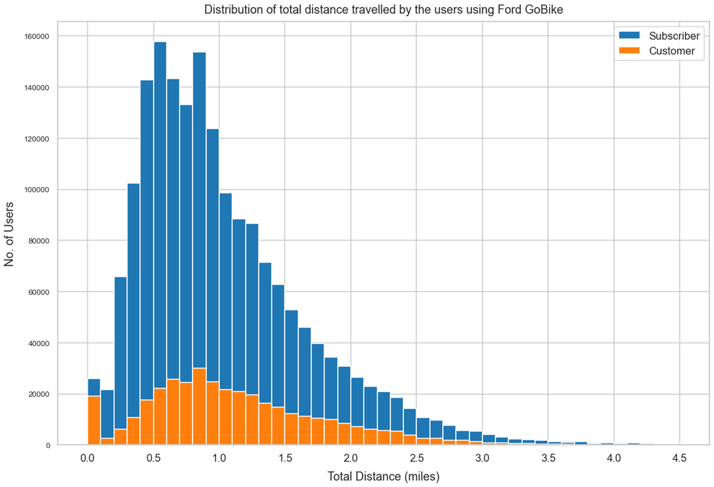

```python
# for bivariate visualization adding two columns for distance_miles and duration_min dividing it into range

plt.figure(figsize = [18,12])
bin_edges = np.arange(0,ford_gobike_copy_df.distance_miles.max()+0.1,0.1)
plt.hist(data = ford_gobike_copy_df.query('user_type == "Subscriber"'), x= 'distance_miles',bins= bin_edges, color = sb.color_palette()[0], label = 'Subscriber')
plt.hist(data = ford_gobike_copy_df.query('user_type == "Customer"'), x= 'distance_miles',bins= bin_edges, color = sb.color_palette()[1], label = 'Customer')
plt.tick_params(axis = 'y',labelsize = 12)
plt.title('Distribution of total distance travelled by the users using Ford GoBike', y = 1.01)
xtick_locs = np.arange(0,ford_gobike_copy_df.distance_miles.max()+0.5,0.5)
plt.xticks(xtick_locs,xtick_locs)
plt.xlabel('Total Distance (miles)', labelpad = 12)
plt.ylabel('No. of Users', labelpad = 12)
plt.legend(["Subscriber","Customer"])
plt.show()
```

```python
#average distance travelled my each subscriber vs each customer

sub_dist_avg = ford_gobike_copy_df.query('user_type == "Subscriber"').distance_miles.sum()/ford_gobike_copy_df.user_type.value_counts()[0]
cust_dist_avg = ford_gobike_copy_df.query('user_type == "Customer"').distance_miles.sum()/ford_gobike_copy_df.user_type.value_counts()[1]
print("Average distance (miles) travelled by each Subscriber = " + str(sub_dist_avg))
print("Average distance (miles) travelled by each Customer = " + str(cust_dist_avg))
```

```
Average distance (miles) travelled by each Subscriber = 1.0341416805531969
Average distance (miles) travelled by each Customer = 1.1354382940328311
```

## Distribution of total duration (Subscribers vs Customers)

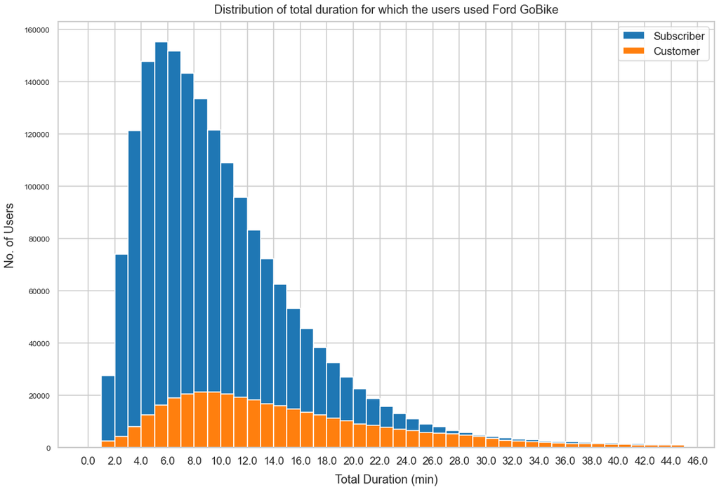

```python
plt.figure(figsize = [18,12])
bin_edges = np.arange(0,ford_gobike_copy_df.duration_min.max()+1, 1)
plt.hist(data = ford_gobike_copy_df.query('user_type == "Subscriber"'), x= 'duration_min',bins= bin_edges, color = sb.color_palette()[0], label = 'Subscriber')
plt.hist(data = ford_gobike_copy_df.query('user_type == "Customer"'), x= 'duration_min',bins= bin_edges, color = sb.color_palette()[1], label = 'Customer')
plt.tick_params(axis = 'y',labelsize = 12)
plt.title('Distribution of total duration for which the users used Ford GoBike', y = 1.01)
xtick_locs = np.arange(0,ford_gobike_copy_df.duration_min.max()+2,2)
plt.xticks(xtick_locs,xtick_locs)
plt.legend(["Subscriber","Customer"])
plt.xlabel('Total Duration (min)', labelpad = 12)
plt.ylabel('No. of Users', labelpad = 12)
plt.show()
```

```python
sub_time_avg = ford_gobike_copy_df.query('user_type == "Subscriber"').duration_min.sum()/ford_gobike_copy_df.user_type.value_counts()[0]
cust_time_avg = ford_gobike_copy_df.query('user_type == "Customer"').duration_min.sum()/ford_gobike_copy_df.user_type.value_counts()[1]
print("Average time duration (min) for travel by each Subscriber = " + str(sub_time_avg))
print("Average time duration (min) for travel by each Customer = " + str(cust_time_avg))
```

```
Average time duration (min) for travel by each Subscriber = 10.30163402446522
Average time duration (min) for travel by each Customer = 15.074042232074882
```

## Distribution of Subscribers and Customers in top 15 Start Station

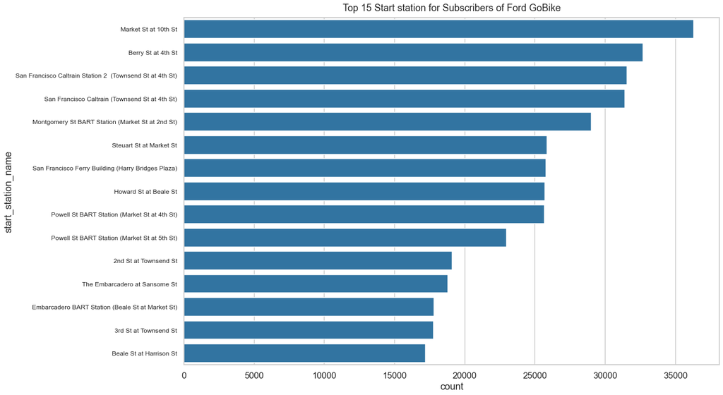

```python
plt.figure(figsize = [18,12])
sub_color = sb.color_palette()[0]
sb.countplot(data = ford_gobike_copy_df.query('user_type == "Subscriber"'), y= 'start_station_name', color = sub_color, order = ford_gobike_copy_df.query('user_type == "Subscriber"').start_station_name.value_counts().sort_values(ascending = False).iloc[:15].index)
plt.tick_params(axis = 'y',which = 'major',labelsize = 12)
plt.title('Top 15 Start station for Subscribers of Ford GoBike', y = 1.01)
plt.show()
```

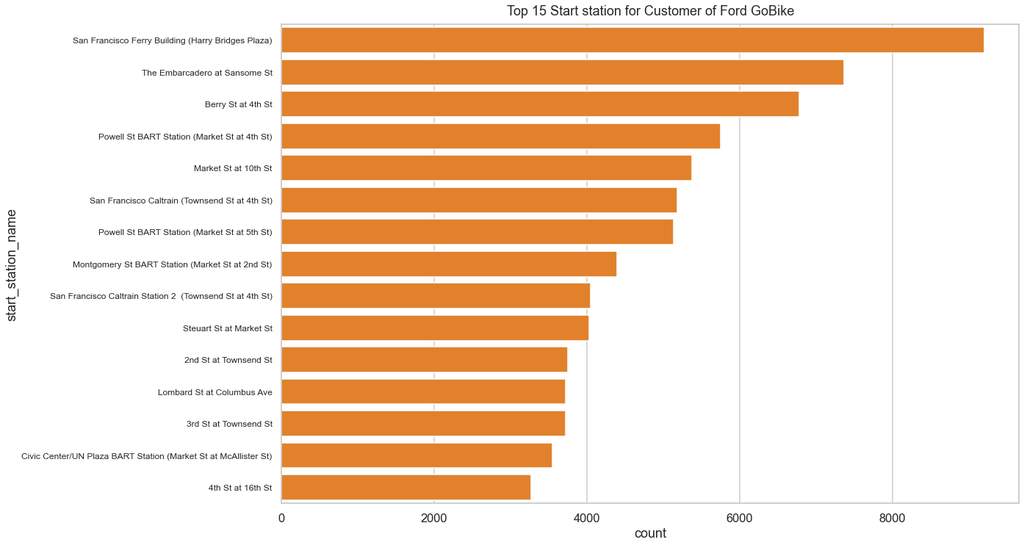

```python
plt.figure(figsize = [18,12])
cust_color = sb.color_palette()[1]
sb.countplot(data = ford_gobike_copy_df.query('user_type == "Customer"'), y= 'start_station_name', color = cust_color, order = ford_gobike_copy_df.query('user_type == "Customer"').start_station_name.value_counts().sort_values(ascending = False).iloc[:15].index)
plt.tick_params(axis = 'y',which = 'major',labelsize = 12)
plt.title('Top 15 Start station for Customer of Ford GoBike', y = 1.01)
plt.show()
```

## Distribution of Subscribers and Customers in top 15 End Station

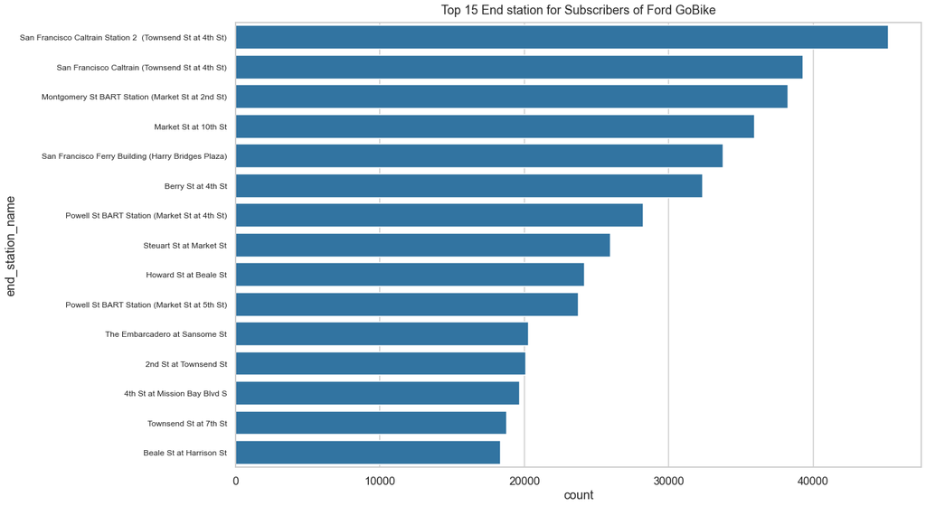

```python
plt.figure(figsize = [18,12])
sub_color = sb.color_palette()[0]
sb.countplot(data = ford_gobike_copy_df.query('user_type == "Subscriber"'), y= 'end_station_name', color = sub_color, order = ford_gobike_copy_df.query('user_type == "Subscriber"').end_station_name.value_counts().sort_values(ascending = False).iloc[:15].index)
plt.tick_params(axis = 'y',which = 'major',labelsize = 12)
plt.title('Top 15 End station for Subscribers of Ford GoBike', y = 1.01)
plt.show()
```

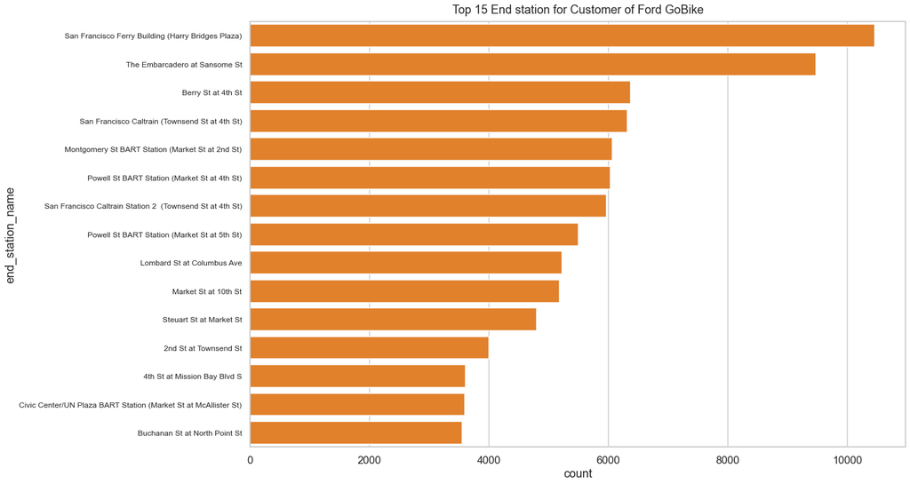

```python
plt.figure(figsize = [18,12])
cust_color = sb.color_palette()[1]
sb.countplot(data = ford_gobike_copy_df.query('user_type == "Customer"'), y= 'end_station_name', color = cust_color, order = ford_gobike_copy_df.query('user_type == "Customer"').end_station_name.value_counts().sort_values(ascending = False).iloc[:15].index)
plt.tick_params(axis = 'y',which = 'major',labelsize = 12)
plt.title('Top 15 End station for Customer of Ford GoBike', y = 1.01)
plt.show()
```

> Although the shape of distribution of top 15 start and end stations looks similar for Subscriber and customer but futher evaluation is needed to look at ratio of customer to subscriber.

> A interesting relation I saw is the users even after paying for subscription of Ford GoBike have total average distance and duration less than that of a normal customer. It should have been other way around.

## Top 15 stations with highest Customer to Subscriber ratio

```python
station_highest_cust_sub_ratio = ((ford_gobike_copy_df.query('user_type == "Customer"').start_station_name.value_counts() + ford_gobike_copy_df.query('user_type == "Customer"').end_station_name.value_counts())/(ford_gobike_copy_df.query('user_type == "Subscriber"').start_station_name.value_counts() + ford_gobike_copy_df.query('user_type == "Subscriber"').end_station_name.value_counts())).sort_values(ascending = False).iloc[:15]
station_highest_cust_sub_ratio
```

```
Newbury Park Dr at King Rd           6.888889
Outside Lands (Temporary Station)    3.551724
19th St at William St                3.400000
MTL-ECO5-01                          3.000000
Bird Ave at Willow St                2.443182
22nd St at William St                2.210526
Folsom St at 7th St                  2.100000
Willow St at Blewett Ave             2.000000
Funston Ave at Fulton St             1.800000
Emory St at The Alameda              1.730769
Turk Blvd at Stanyan St              1.677419
23rd St at Taylor St                 1.655172
7th Ave at Cabrillo St               1.616667
Chestnut St at Van Ness Ave          1.392445
Arguello Blvd at Edward St           1.384615
dtype: float64
```

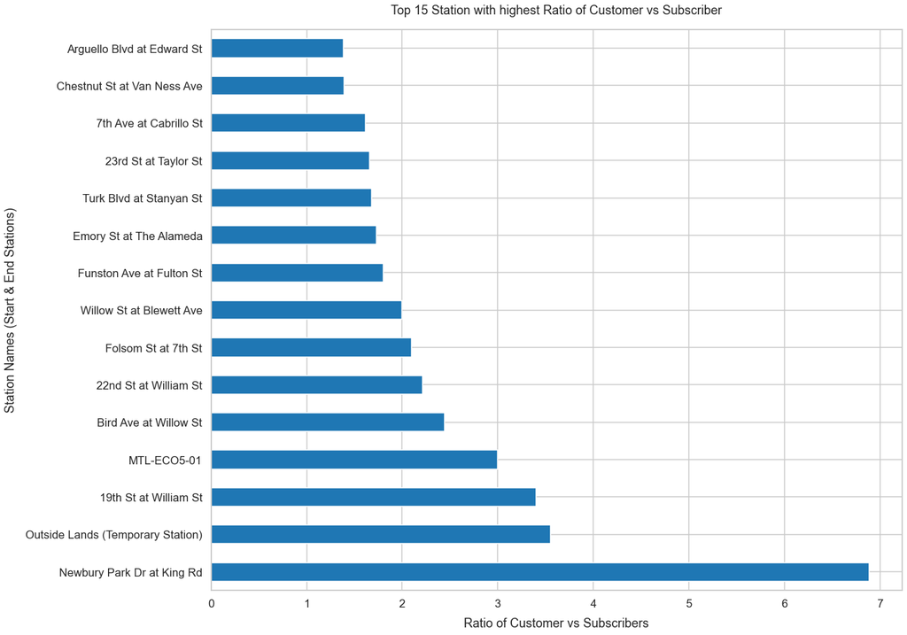

```python
plt.figure(figsize = [18,15])
station_highest_cust_sub_ratio.plot.barh()
plt.xlabel('Ratio of Customer vs Subscribers', labelpad = 12)
plt.ylabel('Station Names (Start & End Stations)', labelpad = 12)
plt.title('Top 15 Station with highest Ratio of Customer vs Subscriber', y = 1.02)
plt.show()
```

> Newbury Park Dr at King Rd has the highest Customer to Subscriber ratio of almost 6.9 which is much higher than other station hence it should be looked into why users of the station do not subscribe

## Distribution of daily Average of Distance (miles) for Subscribers

```python
# segregating subscriber data from whole dataset
heatmap_sub_helper = ford_gobike_copy_df.query('user_type == "Subscriber"')
#groupby start hour and day and then taking mean
heatmap_sub_helper = heatmap_sub_helper.groupby(['start_hour','start_day']).mean()['distance_miles']
heatmap_sub_helper
```

```
start_hour  start_day
0           Fri          0.914179
            Mon          0.792580
            Sat          0.940132
            Sun          0.895792
            Thu          0.879821
                           ...
23          Sat          0.917924
            Sun          0.842258
            Thu          0.900340
            Tue          0.865695
            Wed          0.900786
Name: distance_miles, Length: 168, dtype: float64
```

```python
heatmap_sub_helper = heatmap_sub_helper.unstack(level = 0)
heatmap_sub_helper
```

| start_hour start_day | 0 | 1 | 2 | 3 | 4 | 5 | 6 | 7 | 8 | 9 | ... | 14 | 15 | 16 | 17 | 18 | 19 | 20 | 21 | 22 | 23 |
| --- | --- | --- | --- | --- | --- | --- | --- | --- | --- | --- | --- | --- | --- | --- | --- | --- | --- | --- | --- | --- | --- |
| Fri | 0.914179 | 0.844581 | 0.942255 | 0.998679 | 0.953686 | 1.170539 | 1.096014 | 1.154362 | 1.183801 | 1.102108 | ... | 0.945769 | 0.998283 | 1.044614 | 1.066871 | 1.017346 | 0.978556 | 0.932100 | 0.926487 | 0.941917 | 0.909049 |
| Mon | 0.792580 | 0.798839 | 1.041573 | 0.915639 | 1.090149 | 1.169250 | 1.061171 | 1.143068 | 1.179632 | 1.085010 | ... | 0.942858 | 0.983334 | 1.026880 | 1.071516 | 1.029915 | 0.999853 | 0.948332 | 0.919809 | 0.918124 | 0.859146 |
| Sat | 0.940132 | 0.892729 | 0.952957 | 0.884106 | 0.833710 | 1.046519 | 0.987170 | 1.025315 | 1.027544 | 1.013886 | ... | 1.009390 | 1.002916 | 0.992514 | 0.985910 | 0.948676 | 0.917918 | 0.891128 | 0.893800 | 0.928068 | 0.917924 |
| Sun | 0.895792 | 0.937552 | 1.006514 | 0.932830 | 0.945574 | 1.130154 | 1.142782 | 1.040137 | 1.008650 | 1.004842 | ... | 1.015683 | 0.997976 | 0.973824 | 0.971639 | 0.929502 | 0.880408 | 0.855795 | 0.868769 | 0.854627 | 0.842258 |
| Thu | 0.879821 | 0.819707 | 0.970556 | 1.039398 | 1.069284 | 1.135208 | 1.087168 | 1.145124 | 1.183802 | 1.087856 | ... | 0.930225 | 0.993538 | 1.043003 | 1.081796 | 1.034657 | 0.999574 | 0.967197 | 0.950350 | 0.966492 | 0.900340 |
| Tue | 0.797625 | 0.831686 | 0.952591 | 0.896717 | 1.144465 | 1.169715 | 1.058501 | 1.156311 | 1.178540 | 1.076235 | ... | 0.923686 | 0.983808 | 1.036433 | 1.080443 | 1.033918 | 0.997011 | 0.949248 | 0.958688 | 0.963415 | 0.865695 |
| Wed | 0.866540 | 0.817257 | 0.927393 | 1.048604 | 1.076996 | 1.142354 | 1.078869 | 1.151527 | 1.178222 | 1.088380 | ... | 0.917126 | 0.981250 | 1.034217 | 1.079597 | 1.028437 | 0.998162 | 0.965043 | 0.966109 | 0.948446 | 0.900786 |

7 rows × 24 columns

[figure not shown]

```python
# heatmap visualization
fig, ax = plt.subplots(figsize = (20,12))
sb.heatmap(heatmap_sub_helper, cmap = 'Blues', linewidth = 0.3, square = True, cbar_kws = {"shrink": 0.5})
yticks_labels = ['Mon','Tue','Wed','Thu','Fri','Sat','Sun']
plt.yticks(np.arange(7)+0.5,labels = yticks_labels, rotation = 0)

plt.title('Daily Average of Distance (miles) for Subscribers', y = 1.05)
plt.show()
```

## Distribution of daily Average of Distance (miles) for Customers

```python
# segregating subscriber data from whole dataset
heatmap_cust_helper = ford_gobike_copy_df.query('user_type == "Customer"')
#groupby start hour and day and then taking mean
heatmap_cust_helper = heatmap_cust_helper.groupby(['start_hour','start_day']).mean()['distance_miles']
heatmap_cust_helper
```

```
start_hour  start_day
0           Fri          0.886326
            Mon          0.845622
            Sat          0.898038
            Sun          0.903047
            Thu          0.912016
                           ...
23          Sat          0.958190
            Sun          0.932238
            Thu          1.007175
            Tue          1.001321
            Wed          1.008038
Name: distance_miles, Length: 168, dtype: float64
```

```python
heatmap_cust_helper = heatmap_cust_helper.unstack(level = 0)
heatmap_cust_helper
```

| start_hour start_day | 0 | 1 | 2 | 3 | 4 | 5 | 6 | 7 | 8 | 9 | ... | 14 | 15 | 16 | 17 | 18 | 19 | 20 | 21 | 22 | 23 |
| --- | --- | --- | --- | --- | --- | --- | --- | --- | --- | --- | --- | --- | --- | --- | --- | --- | --- | --- | --- | --- | --- |
| Fri | 0.886326 | 0.866389 | 0.850250 | 1.069653 | 0.961444 | 1.075805 | 1.217220 | 1.327853 | 1.381879 | 1.268520 | ... | 1.071831 | 1.108790 | 1.130281 | 1.180377 | 1.138895 | 1.045677 | 1.005537 | 0.976340 | 0.960257 | 1.004377 |
| Mon | 0.845622 | 0.767466 | 1.048776 | 1.166279 | 0.894702 | 0.979700 | 1.114281 | 1.305599 | 1.372709 | 1.221395 | ... | 1.068519 | 1.093674 | 1.136152 | 1.199536 | 1.164381 | 1.070329 | 1.040206 | 1.020050 | 1.040861 | 0.916610 |
| Sat | 0.898038 | 0.897978 | 0.897558 | 0.920823 | 0.902878 | 1.029762 | 1.035848 | 1.160992 | 1.139670 | 1.174136 | ... | 1.111786 | 1.096386 | 1.113265 | 1.080653 | 1.054819 | 1.002502 | 0.991600 | 0.956838 | 0.984183 | 0.958190 |
| Sun | 0.903047 | 0.930291 | 0.889667 | 0.792365 | 0.888561 | 1.271426 | 1.077944 | 1.154595 | 1.137671 | 1.146394 | ... | 1.094953 | 1.093509 | 1.102687 | 1.061970 | 1.034078 | 0.996634 | 0.984080 | 0.946230 | 0.906886 | 0.932238 |
| Thu | 0.912016 | 0.910428 | 0.872594 | 1.165329 | 0.993286 | 1.012081 | 1.077243 | 1.304814 | 1.388659 | 1.228372 | ... | 1.026916 | 1.080998 | 1.134943 | 1.201514 | 1.150785 | 1.098770 | 1.101072 | 1.068087 | 1.089161 | 1.007175 |
| Tue | 0.818179 | 1.036286 | 0.924888 | 1.073506 | 0.939050 | 1.044322 | 1.117454 | 1.322838 | 1.359053 | 1.221991 | ... | 1.037599 | 1.078621 | 1.146243 | 1.202920 | 1.155711 | 1.093262 | 1.059042 | 1.015123 | 1.015332 | 1.001321 |
| Wed | 0.955143 | 0.944697 | 0.782721 | 1.394048 | 0.991116 | 1.115925 | 1.128684 | 1.281823 | 1.370350 | 1.212463 | ... | 1.042727 | 1.073658 | 1.146076 | 1.225171 | 1.168195 | 1.084645 | 1.052468 | 1.067504 | 1.066525 | 1.008038 |

7 rows × 24 columns

[figure not shown]

```python
# heatmap visualization
fig, ax = plt.subplots(figsize = (20,12))
sb.heatmap(heatmap_cust_helper, cmap = 'Oranges', linewidth = 0.3, square = True, cbar_kws = {"shrink": 0.5})
yticks_labels = ['Mon','Tue','Wed','Thu','Fri','Sat','Sun']
plt.yticks(np.arange(7)+0.5,labels = yticks_labels, rotation = 0)

plt.title('Daily Average of Distance (miles) for Customers', y = 1.05)
plt.show()
```

> The distribution above shows average distance travelled is more in the morning (5 am to 9 am) and then for the rest of the day till 11pm the average distance travalled is similar in case of Customers.

## Distribution of daily Average of usage Duration (min) for Subscriber

```python
# segregating subscriber data from whole dataset
heatmap_duration_sub_helper = ford_gobike_copy_df.query('user_type == "Subscriber"')
#groupby start hour and day and then taking mean
heatmap_duration_sub_helper = heatmap_duration_sub_helper.groupby(['start_hour','start_day']).mean()['duration_min']
heatmap_duration_sub_helper
```

```
start_hour  start_day
0           Fri          9.663863
            Mon          9.550559
            Sat          9.935965
            Sun          9.472920
            Thu          9.742474
                           ...
23          Sat          9.904116
            Sun          9.097037
            Thu          9.414538
            Tue          8.976092
            Wed          9.145833
Name: duration_min, Length: 168, dtype: float64
```

```python
heatmap_duration_sub_helper = heatmap_duration_sub_helper.unstack(level = 0)
heatmap_duration_sub_helper
```

| start_hour start_day | 0 | 1 | 2 | 3 | 4 | 5 | 6 | 7 | 8 | 9 | ... | 14 | 15 | 16 | 17 | 18 | 19 | 20 | 21 | 22 | 23 |
| --- | --- | --- | --- | --- | --- | --- | --- | --- | --- | --- | --- | --- | --- | --- | --- | --- | --- | --- | --- | --- | --- |
| Fri | 9.663863 | 9.572933 | 10.218941 | 11.582191 | 9.559598 | 9.557937 | 9.101395 | 9.843545 | 10.384333 | 10.123691 | ... | 10.415979 | 10.493441 | 10.407701 | 10.694959 | 10.532366 | 10.455961 | 10.243284 | 10.169394 | 10.167142 | 9.808272 |
| Mon | 9.550559 | 9.773864 | 11.399496 | 10.520772 | 10.910777 | 9.543833 | 8.901776 | 9.908407 | 10.607867 | 10.185755 | ... | 10.238587 | 10.351010 | 10.147115 | 10.545364 | 10.234314 | 10.080750 | 9.809737 | 9.482546 | 9.448030 | 8.989961 |
| Sat | 9.935965 | 9.985494 | 10.237793 | 10.270517 | 10.626383 | 10.436270 | 10.324370 | 10.314871 | 9.970598 | 10.236197 | ... | 11.733127 | 11.714863 | 11.351735 | 11.189942 | 10.826026 | 10.535782 | 10.358108 | 10.048379 | 10.341694 | 9.904116 |
| Sun | 9.472920 | 9.940930 | 10.297885 | 11.010810 | 12.558377 | 11.290610 | 12.369790 | 10.811332 | 10.196199 | 10.196399 | ... | 11.898370 | 11.688357 | 11.338527 | 10.918153 | 10.553184 | 10.171475 | 9.926180 | 9.393334 | 9.179464 | 9.097037 |
| Thu | 9.742474 | 9.462339 | 10.429957 | 10.959259 | 9.930923 | 9.196823 | 9.002777 | 9.807828 | 10.501314 | 10.027202 | ... | 10.201341 | 10.372190 | 10.295743 | 10.708321 | 10.339125 | 10.223253 | 10.031008 | 9.951574 | 9.974985 | 9.414538 |
| Tue | 9.067804 | 9.617520 | 9.979356 | 10.151996 | 10.456087 | 9.342898 | 8.902050 | 9.914864 | 10.544669 | 10.037580 | ... | 9.990831 | 10.262687 | 10.203677 | 10.661920 | 10.339153 | 10.193262 | 9.902802 | 9.856748 | 9.781206 | 8.976092 |
| Wed | 9.825135 | 9.681634 | 10.903193 | 12.097764 | 9.532790 | 9.085153 | 9.067685 | 9.884615 | 10.501999 | 10.096788 | ... | 10.092979 | 10.207240 | 10.162748 | 10.710900 | 10.342476 | 10.266434 | 10.067007 | 9.771767 | 9.555248 | 9.145833 |

7 rows × 24 columns

[figure not shown]

```python
# heatmap visualization
fig, ax = plt.subplots(figsize = (20,12))
sb.heatmap(heatmap_duration_sub_helper, cmap = 'Blues', linewidth = 0.3, square = True, cbar_kws = {"shrink": 0.5})
yticks_labels = ['Mon','Tue','Wed','Thu','Fri','Sat','Sun']
plt.yticks(np.arange(7)+0.5,labels = yticks_labels, rotation = 0)

plt.title('Daily Average of Duration (min) for Subscribers', y = 1.05)
plt.show()
```

## Distribution of daily Average of usage Duration (min) for Customer

```python
# segregating subscriber data from whole dataset
heatmap_duration_cust_helper = ford_gobike_copy_df.query('user_type == "Customer"')
#groupby start hour and day and then taking mean
heatmap_duration_cust_helper = heatmap_duration_cust_helper.groupby(['start_hour','start_day']).mean()['duration_min']
heatmap_duration_cust_helper
```

```
start_hour  start_day
0           Fri          12.884737
            Mon          14.102092
            Sat          13.575223
            Sun          13.845760
            Thu          12.818667
                           ...
23          Sat          13.831064
            Sun          13.532344
            Thu          13.335140
            Tue          12.985097
            Wed          13.320569
Name: duration_min, Length: 168, dtype: float64
```

```python
heatmap_duration_cust_helper = heatmap_duration_cust_helper.unstack(level = 0)
heatmap_duration_cust_helper
```

| start_hour start_day | 0 | 1 | 2 | 3 | 4 | 5 | 6 | 7 | 8 | 9 | ... | 14 | 15 | 16 | 17 | 18 | 19 | 20 | 21 | 22 | 23 |
| --- | --- | --- | --- | --- | --- | --- | --- | --- | --- | --- | --- | --- | --- | --- | --- | --- | --- | --- | --- | --- | --- |
| Fri | 12.884737 | 12.982890 | 13.227824 | 12.820417 | 12.800260 | 9.651349 | 11.377514 | 12.252938 | 13.360442 | 13.393057 | ... | 16.611275 | 15.981836 | 15.103152 | 14.734456 | 14.558447 | 14.419783 | 14.350838 | 14.263761 | 14.016927 | 13.994345 |
| Mon | 14.102092 | 15.836061 | 14.817760 | 16.353459 | 12.197701 | 10.116100 | 10.048102 | 12.377782 | 13.458380 | 13.497474 | ... | 17.166833 | 16.375607 | 14.891414 | 14.426601 | 14.055563 | 13.433171 | 13.559004 | 13.164345 | 13.872683 | 12.981972 |
| Sat | 13.575223 | 12.996139 | 13.642338 | 14.927827 | 14.990625 | 13.659048 | 12.291711 | 15.213706 | 14.917652 | 15.927316 | ... | 18.351666 | 18.380896 | 18.492607 | 17.488247 | 16.493330 | 15.643310 | 15.664877 | 15.464312 | 14.875383 | 13.831064 |
| Sun | 13.845760 | 14.312759 | 15.356924 | 14.515769 | 17.317949 | 16.106701 | 13.758133 | 14.615818 | 15.024208 | 16.332103 | ... | 18.004101 | 17.994243 | 17.893387 | 16.852553 | 15.811693 | 15.937224 | 15.038415 | 14.477958 | 14.718310 | 13.532344 |
| Thu | 12.818667 | 12.768830 | 13.107512 | 12.867544 | 13.168362 | 9.910256 | 10.284223 | 12.268172 | 13.390202 | 13.151595 | ... | 16.008820 | 15.572204 | 14.593992 | 14.362669 | 14.057701 | 13.784263 | 13.950106 | 13.789000 | 13.521521 | 13.335140 |
| Tue | 13.004762 | 14.963418 | 16.092029 | 14.363141 | 11.025962 | 10.861003 | 10.193120 | 12.442445 | 13.082682 | 13.016099 | ... | 16.056102 | 15.767228 | 14.446689 | 14.066816 | 13.760485 | 13.772518 | 13.420042 | 13.090110 | 12.979944 | 12.985097 |
| Wed | 14.533106 | 15.542355 | 14.894262 | 14.058730 | 11.179348 | 10.504677 | 10.379642 | 12.196063 | 13.319505 | 13.052750 | ... | 15.754757 | 15.357278 | 14.308985 | 14.366990 | 13.977666 | 13.689873 | 13.277568 | 13.444166 | 13.588713 | 13.320569 |

7 rows × 24 columns

[figure not shown]

```python
# heatmap visualization
fig, ax = plt.subplots(figsize = (20,12))
sb.heatmap(heatmap_duration_cust_helper, cmap = 'Oranges', linewidth = 0.3, square = True, cbar_kws = {"shrink": 0.5})
yticks_labels = ['Mon','Tue','Wed','Thu','Fri','Sat','Sun']
plt.yticks(np.arange(7)+0.5,labels = yticks_labels, rotation = 0)

plt.title('Daily Average of Duration (min) for Customers', y = 1.05)
plt.show()
```

> The distribution does not correalates to above heatmap of average distance for Customers shows average duration of travel is more at noon 10 am to 3 pm and least during early morning hours 4 am to 7 am.